# W3cubDocs

## Emailing receipts

1. [Log in](https://www.npmjs.com/login) to npm with your user account.
2. In the upper right corner of the page, click your profile picture, then click **Account**.
3. In the left sidebar, click the name of the organization whose billing receipts you want to email.
4. On the organization settings page, click **Billing**.
5. On the Billing Information page, under "monthly bill", select **View Billing History**.
6. To email a single receipt, find the row of the receipt you want to download, then, on the right side of the row, click the email icon.

[figure not shown]

7. To email multiple receipts, first select the receipts that you wish to download by selecting the box next to the date. To select all receipts, select the checkbox next to the "Date" header. Then click **Email Checked**.

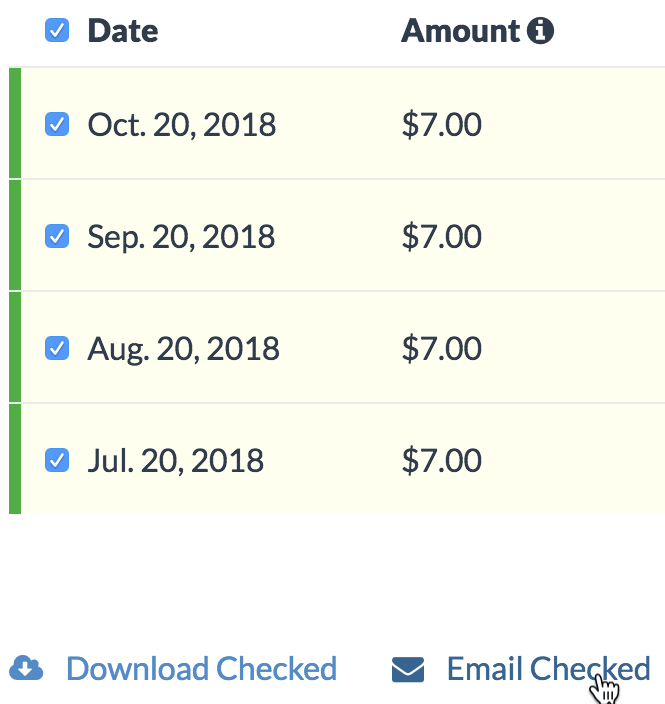

8. In the Email Receipt dialog box, fill in the "From", "To", and "Message" fields.

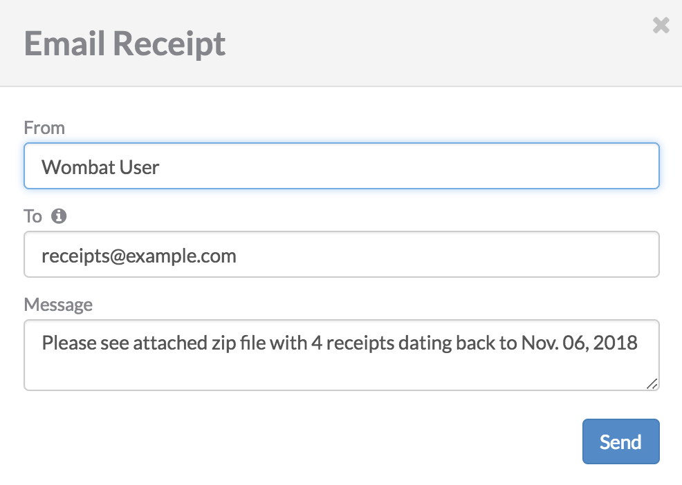

9. Click **Send**.